# Learning objectives

1. You can keep or drop columns from a data frame using the `select()` function from the {dplyr} package.
2. You can select a range or combination of columns using operators like the colon (`:`), the exclamation mark (`!`), and the `c()` function.

# 1 Introduction to the dataset

In this lesson, we analyse results from a COVID-19 serological survey conducted in Yaounde, Cameroon in late 2020.

```r
yaounde <- read_csv(here("ch99_template/data/yaounde_data.csv"))
yaounde
```

| id | date_surveyed | age | age_category | sex | highest_education | occupation | weight_kg | height_cm | is_smoker | is_pregnant | is_medicated | neighborhood | household_with_children | breadwinner | source_of_revenue | has_contact_covid | igg_result | igm_result | symptoms | consultation | treatment_combinations | drugsource | hospitalised | sequelae | respiration_frequency | is_drug_parac | is_drug_antibio | is_drug_hydrocortisone | is_drug_other_anti_inflam | … |
| --- | --- | --- | --- | --- | --- | --- | --- | --- | --- | --- | --- | --- | --- | --- | --- | --- | --- | --- | --- | --- | --- | --- | --- | --- | --- | --- | --- | --- | --- | --- |
| BRIQUETERIE_000_0001 | 2020-10-22 | 45 | 45 - 64 | Female | Secondary | Informal worker | 95 | 169 | Non-smoker | No | Yes | Briqueterie | No children | No response | Other | Recent COVID contact | Negative | Negative | Muscle pain | NA | Paracetamol | Self or familial | No | NA | NA | 1 | 0 | 0 | 0 | … |
| BRIQUETERIE_000_0002 | 2020-10-24 | 55 | 45 - 64 | Male | University | Salaried worker | 96 | 185 | Ex-smoker | NA | No | Briqueterie | No children | Other family | Regular, Formal--Regular, Commerce | No COVID contact | Positive | Negative | No symptoms | NA | NA | NA | No | NA | NA | NA | NA | NA | NA | … |
| BRIQUETERIE_000_0003 | 2020-10-24 | 23 | 15 - 29 | Male | University | Student | 74 | 180 | Smoker | NA | Yes | Briqueterie | No children | No response | Other | No COVID contact | Negative | Negative | No symptoms | NA | NA | NA | Yes, but not COVID-linked | NA | NA | NA | NA | NA | NA | … |
| BRIQUETERIE_002_0001 | 2020-10-22 | 20 | 15 - 29 | Female | Secondary | Student | 70 | 164 | Non-smoker | No | No | Briqueterie | With children | Mother | Irregular, Commerce | No COVID contact | Positive | Negative | Rhinitis--Sneezing--Anosmia or ageusia | NA | Antibiotics | Self or familial | No | NA | NA | 0 | 1 | 0 | 0 | … |
| BRIQUETERIE_002_0002 | 2020-10-22 | 55 | 45 - 64 | Female | Primary | Trader--Farmer | 67 | 147 | Non-smoker | No | No | Briqueterie | With children | Mother | Regular, Informal--Irregular, Commerce--Other | No COVID contact | Positive | Negative | No symptoms | NA | NA | NA | No | NA | NA | NA | NA | NA | NA | … |
| BRIQUETERIE_002_0003 | 2020-10-25 | 17 | 15 - 29 | Female | Secondary | Student | 65 | 162 | Non-smoker | No | No | Briqueterie | With children | No response | Irregular, Commerce | No COVID contact | Negative | Negative | Fever--Cough--Rhinitis--Nausea or vomiting--Diarrhoea | Private clinic | Paracetamol--Antibiotics | Pharmacist | No | NA | NA | 1 | 1 | 0 | 0 | … |
| BRIQUETERIE_002_0004 | 2020-10-25 | 13 | 5 - 14 | Female | Secondary | Student | 65 | 150 | Non-smoker | No | No | Briqueterie | With children | No response | Other | No COVID contact | Positive | Negative | Sneezing | NA | Traditional meds. | Self or familial | No | NA | NA | 0 | 0 | 0 | 0 | … |
| BRIQUETERIE_003_0001 | 2020-10-24 | 28 | 15 - 29 | Male | Doctorate | Student | 62 | 173 | Non-smoker | NA | No | Briqueterie | With children | No response | Irregular, Formal--Irregular, Commerce | No COVID contact | Negative | Negative | Headache | NA | Paracetamol | Self or familial | No | NA | NA | 1 | 0 | 0 | 0 | … |
| BRIQUETERIE_003_0002 | 2020-10-24 | 30 | 30 - 44 | Male | Secondary | Trader | 73 | 170 | Non-smoker | NA | No | Briqueterie | With children | No response | Irregular, Formal--Irregular, Commerce | No COVID contact | Negative | Negative | Fever--Rhinitis--Anosmia or ageusia | NA | Paracetamol--Traditional meds. | Doctor--Self or familial | No | NA | NA | 1 | 0 | 0 | 0 | … |
| BRIQUETERIE_003_0003 | 2020-10-24 | 13 | 5 - 14 | Female | Secondary | Other | 56 | 153 | Non-smoker | No | No | Briqueterie | With children | No response | Irregular, Formal--Irregular, Commerce | No COVID contact | Positive | Negative | No symptoms | NA | NA | NA | No | NA | NA | NA | NA | NA | NA | … |

[output cut: 961 more lines]

# 2 Introducing `select()`

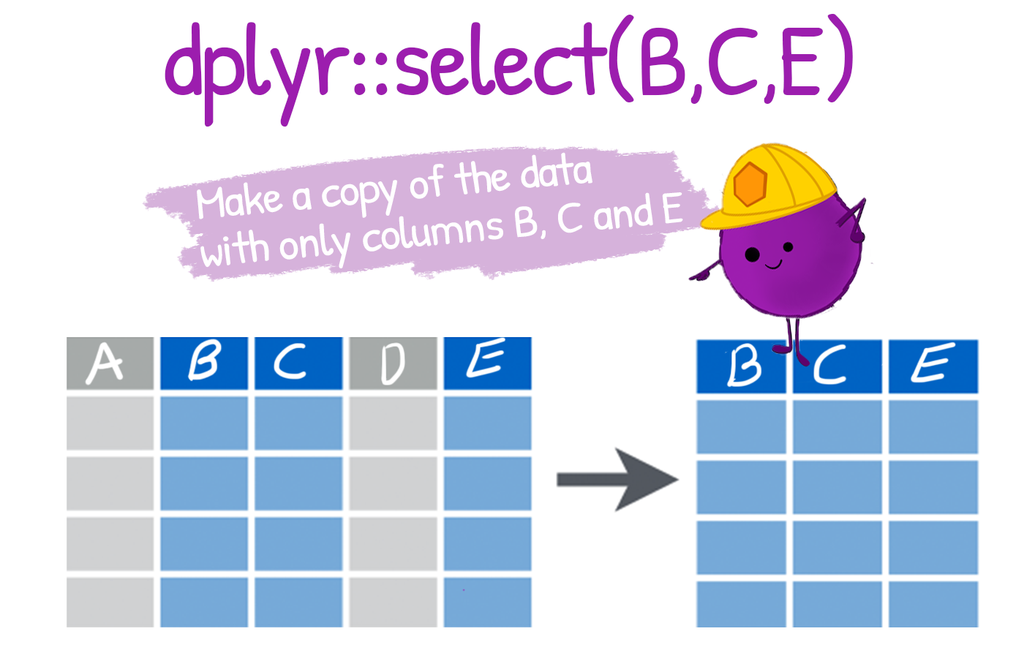

`dplyr::select()` lets you pick which columns (variables) to keep or drop from a data frame.

You can select a column *by name*:

```r
yaounde %>% select(age)
```

| age |
| --- |
| 45 |
| 55 |
| 23 |
| 20 |
| 55 |
| 17 |
| 13 |
| 28 |
| 30 |
| 13 |

[output cut: 961 more lines]

Or you can select a column *by position*:

```r
yaounde %>% select(6)
```

| highest_education |
| --- |
| Secondary |
| University |
| University |
| Secondary |
| Primary |
| Secondary |
| Secondary |
| Doctorate |
| Secondary |
| Secondary |

[output cut: 961 more lines]

◘ From the `yaounde` data frame, select the `age_category` column.

```r
# Type your answer:
Q_age_category <- yaounde %>% _____________________
```

◘ From the `yaounde` data frame, select the 14th column.

```r
# Type your answer:
Q_14th_column <- yaounde %>% ____________________
```

◘ What package does the `select()` function come from?

```
A. {rmarkdown}

B. {dplyr}

C. {ggplot2}
```

```r
# Delete the incorrect lines and run the correct line
Q_select_package <- "A"
Q_select_package <- "B"
Q_select_package <- "C"
```

# 3 Other divs

An example of a “key point” div.

An example of a “watch out” div.

An example of a “challenge” div.

An example of a “vocab” div.

An example of a “recap” div.

An example of an “rstudio-cloud” div. For steps specific to those working on the cloud.

An example of an “error” div. Anticipate and provide solutions to common errors.

**Remember XYZ syntax**

An example of a “reminder” div with a within-div title.

An example of a “side note” div.

```r
"a 'side note' div with a code chunk"
```

```
## [1] "a 'side note' div with a code chunk"
```

An example of a “pro tip” div.

```r
"a 'pro tip' div with a non-evaluated code chunk"
```

# Contributors

The following team members contributed to this lesson:

- [LAURE VANCAUWENBERGHE](https://thegraphcourses.org/members/lolovanco)  
  Data analyst, the GRAPH Network

  A firm believer in science for good, striving to ally programming, health and education.
- [KENE DAVID NWOSU](https://thegraphcourses.org/members/kendavidn/)  
  Data analyst, the GRAPH Network

  Passionate about education.
- [JOY VAZ](https://thegraphcourses.org/members/joy)  
  R Developer and Instructor, The Graph Network

  Loves doing science and teaching science.
- [ANDREE VALLE CAMPOS](https://thegraphcourses.org/members/avallecam/)  
  R Developer and Instructor, The Graph Network

  Motivated by reproducible science and education.
- [MATTEO FRANZA](https://thegraphcourses.org/members/mfr)  
  PhD at EPFL

  This is a temporary tagline
- [BENEDICT NGUIMBIS](https://thegraphcourses.org/members/benguimbis)  
  Data analyst, the GRAPH Network

  This is a temporary tagline
- DANIEL CAMARA  
  Data Scientist at the GRAPH Network and fellowship as Public Health researcher at Fiocruz, Brazil

  Passionate about lots of things, especially when it involves people leading lives with more equality and freedom
- [LAMECK AGASA](https://thegraphcourses.org/members/ondieki)  
  Statistician/Data Scientist

  This is a temporary tagline
- [MICHAL SHRESTHA](https://thegraphcourses.org/members/michals)  
  Global Health Researcher, the GRAPH Network

  This is a temporary tagline
- [AMA KORANTEMA OWUSU-DARKO](https://thegraphnetwork.training/members/aowusuda/)  
  Data Analyst

  Passionate about equipping health professionals with data analysis skills to promote evidence based research.
- [EDUARDO ARAUJO](https://thegraphcourses.org/members/eduardo_araujo/)  
  Student at Universidade Tecnologica Federal do Parana

  Passionate about reproducible science and education.
- [AZIZA MERZOUKI](https://thegraphcourses.org/members/aziza)  
  Data Scientist & Postdoc, University of Geneva

  Passionate about data driven decision making, enjoying to uncover the story and explanation behind data

# References

Some material in this lesson was adapted from the following sources:

- Horst, Allison. “Allisonhorst/Dplyr-Learnr: A Colorful Introduction to Some Common Functions in Dplyr, Part of the Tidyverse.” GitHub. Accessed April 6, 2022. https://github.com/allisonhorst/dplyr-learnr.

This work is licensed under the [Creative Commons Attribution Share Alike](https://creativecommons.org/licenses/by-sa/4.0/) license.